# Effects of Trip characteristics on their Duration

## By Ajayi Temiloluwa

In this section of this project, an explanatory data analysis is conducted on the Ford GoBike dataset.

Ford GoBike is a regional public bike sharing system in the San Francisco Bay Area, California. The dataset used for this explanatory analysis consists of monthly individual trip data from February, 2019 in CSV format covering the greater San Francisco Bay area.

## Distribution of Trip Duration in minutes and Rider's age.

The trip duration in minutes takes a scale between 1 and 1409 minutes, with most of the values between 2 and 20, there was a need to specify new bins. The distribution is right skewed and takes a unimodal shape.

The age of the rider takes a scale between 18 and 141 yrs, with most of the values between 20 and 45, there was a need to specify new bins. The distribution is right skewed and takes a unimodal shape.

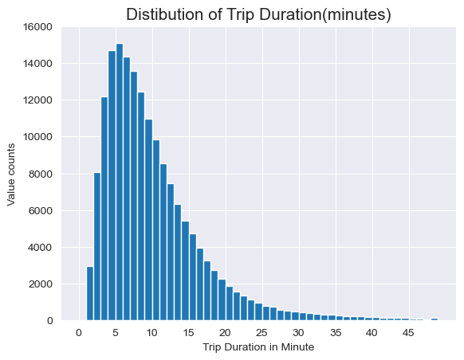

## Distribution of Trip Duration in Rider's age.

The age of the rider takes a scale between 18 and 141 yrs, with most of the values between 20 and 45, there was a need to specify new bins. The distribution is right skewed and takes a unimodal shape.

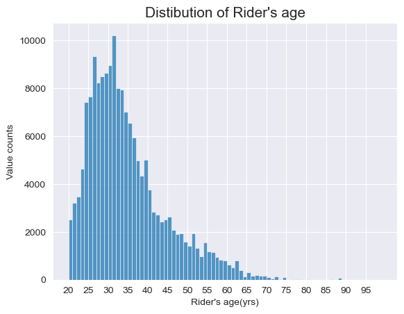

## Distribution of member gender.

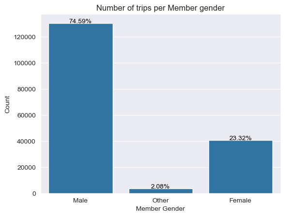

## Distribution of User types.

90.5% of the users were subscribers, while only 9.5% were customers(one-off users.

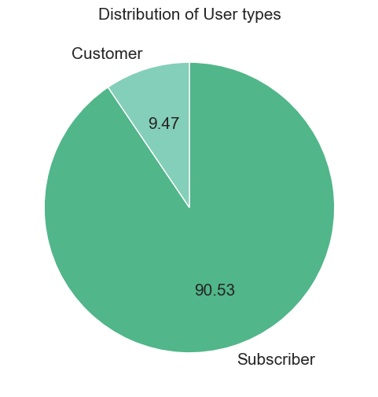

Week days (between Monday and Friday) activities are high with the highest number of trips in a being on Thursday(19.3% of the weekly trips). A total of 16.5% of the trips were made on weekends(sunday and saturday). This reflects that most of the trips were made for Schooling and Working purposes and only a little made for recreational purposes.

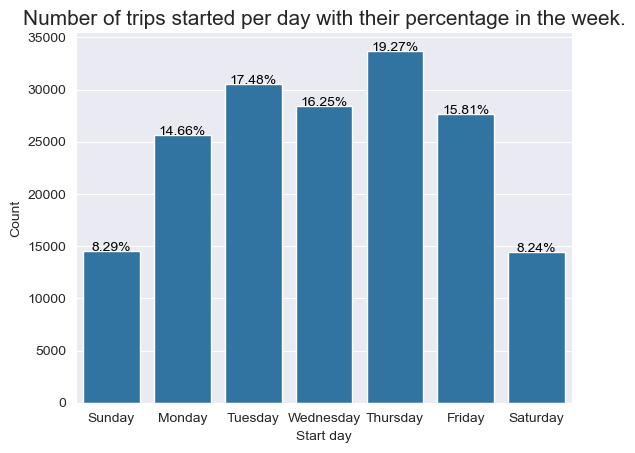

## Average Trip duration for each day

Despite fewer trips were made on weekends, trips made on weekends were longer as most probably they were enjoyed or uses as exercises. During weekdays, riders ride for a shorter time to a more define location like school and workplace.

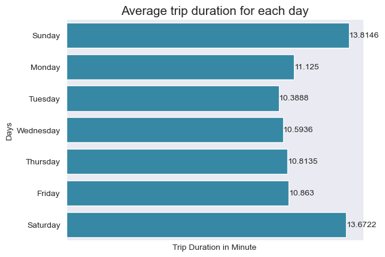

## Average trip duration per day for each gender

For each day, the duration of trip for each gender group were compared. It can be noticed that those in the otherd group rode longer with an average of 23 minutes on Sundays. Females also ride for a longer time when compared to males. All gender ride for a longer time during weekends.

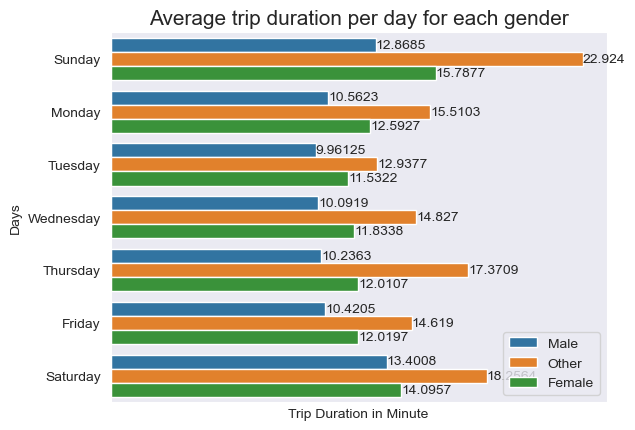

## Average Trip Duration in Minute for each user type

Costumers generally ride for a far longer time when compare to subscribers. Probably, this is due to the fact that costumer ride occasionally during weekdays.

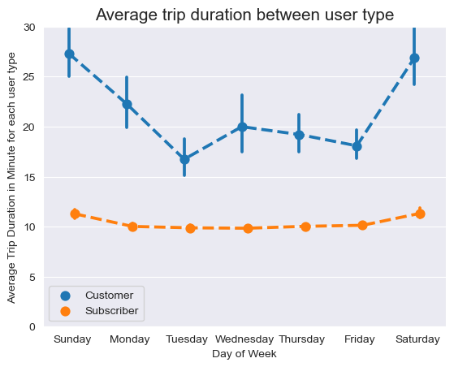